# Spicknall

Jakub

4th October

# Models based on Spicknall`s review

The models include the susceptible population S, the population infected by sensitive strain I<sub>w</sub>, the population infected by resistant strain I<sub>z</sub> and eventually the population infected by both I<sub>zw</sub>. Every model starts with S=0.98, I<sub>w</sub>=0.01 and I<sub>z</sub>=0.01 at t=0. We then follow the evolution of these population during 2000 steps.

The mechanism of resistance has its cost in terms of transmission (for example because of lower reproduction rate of bacteria and therefore less bacteria are transmitted during the contact). This phenomenon is taken into account by the choice of $\beta$<sub>z</sub> and $\beta$<sub>w</sub>. $\beta$<sub>z</sub> is lower than $\beta$<sub>w</sub> and therefore the transmission takes place at a lower rate in resistant strain.

## Single-strain model

This model is based on an independent evolution of the resistant and sensitive strain and doesn`t therefore incude any competition.

The model is defined by following equations:

$$\begin{aligned}
\frac{dS_1}{dt} &= -\beta_w \times{I_w}\times{S_1} + \gamma\times(1-\epsilon)\times{I_w} + \gamma ` \times \epsilon \times {I_w} \\
\frac{dI_w}{dt} &=\beta_w \times{I_w}\times{S_1} - \gamma\times(1-\epsilon)\times{I_w}- \gamma ` \times \epsilon \times {I_w} \\
\frac{dS_2}{dt} &= -\beta_z \times{I_z}\times{S_2} + \gamma \times {I_z} \\
\frac{dI_z}{dt} &=\beta_z \times{I_z}\times{S_2} - \gamma \times {I_z} \\
\end{aligned}$$

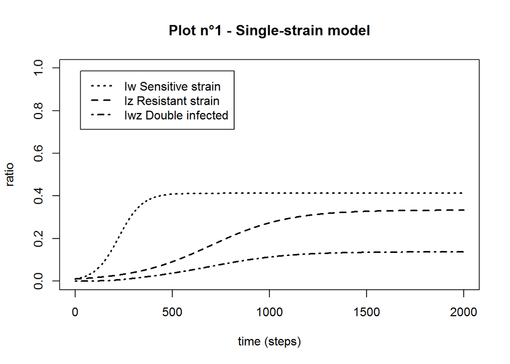

**Plot n°1 Single-strain model**: $\beta$ <sub>w</sub> = 0.04, $\beta$ <sub>z</sub> = 0.015, $\gamma$ = 0.01, $\gamma$` = 0.1 and $\epsilon$ = 0.15 are the chosen values of parameters. We follow the evolution of population infected with sensitive strain (*dotted line*), with resistant strain (*dashed line*) and with both (*dashed-dotted line*) over 2000 steps.

## Superinfection model

In this model, the hosts can be infected with both resistant and sensitive strains, I<sub>wz</sub> corresponding to this subpopulation. This superinfected subpopulation of host can then transmit the one or another strain but with dampened contagiousness, that is represented by the ratio q in the model.

The model is defined by following equations:

$$\begin{aligned}
\frac{dS}{dt} &=-{\beta_w} \times({I_w}+{q}\times{I_{wz}})\times{S} -{\beta_z} \times({I_z}+{q}\times{I_{wz}})\times{S} + {\gamma} \times {I_z} + {\gamma}\times(1-{\epsilon})\times{I_w} + {\gamma `} \times {\epsilon} \times {I_w} \\
\frac{dI_w}{dt} &={\beta_w} \times({I_w}+{q}\times{I_{wz}})\times{S} + {\gamma} \times {I_{wz}} - {\beta_z} \times({I_z}+{q}\times{I_{wz}})\times{I_w}- {\gamma}\times(1-{\epsilon})\times{I_w}- {\gamma `}\times {\epsilon} \times {I_w} \\
\frac{dI_z}{dt} &={\beta_z} \times({I_z}+{q}\times{I_{wz}})\times{S} + {\gamma}\times(1-{\epsilon})\times{I_{wz}} + {\gamma `} \times {\epsilon} \times {I_{wz}} - {\beta_w} \times({I_w}+{q}\times{I_{wz}})\times{I_z} - {\gamma} \times {I_z} \\
\frac{dI_{wz}}{dt} &={\beta_z} \times({I_z}+{q}\times{I_{wz}})\times{I_w}+{\beta_w} \times({I_w}+{q}\times{I_{wz}})\times{I_z}-{\gamma} \times {I_{wz}} -{\gamma}\times(1-{\epsilon})\times{I_{wz}} - {\gamma `} \times {\epsilon} \times {I_{wz}} \\
\end{aligned}$$

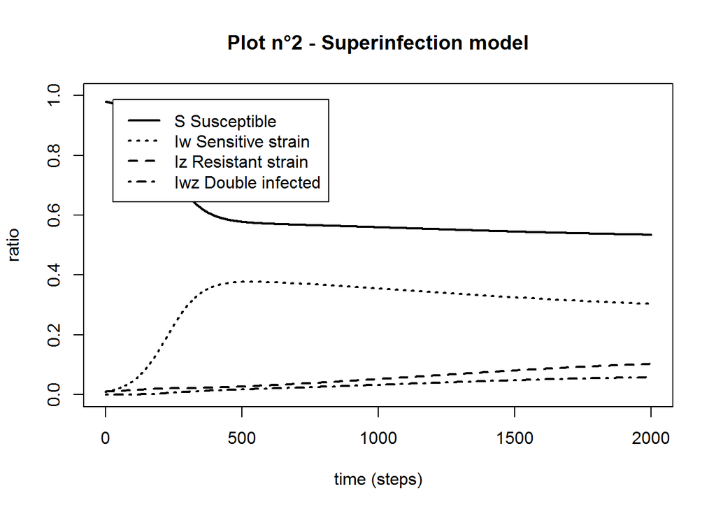

**Plot n°2 Superinfection model**:$\beta$ <sub>w</sub> = 0.04, $\beta$ <sub>z</sub> = 0.015, $\gamma$ = 0.01, $\gamma$`= 0.1, $\epsilon$ = 0.15 and $q$=0.5 are the chosen values of parameters. We follow the evolution of the sensitive subpopulation (*solid line*), the subpopulation infected with sensitive strain exclusively (*dotted line*), with resistant strain exclusively (*dashed line*) and with both (*dashed-dotted line*) over 2000 steps.

## Exclusive infection model

This model is based on a relatively independent evolution of the resistant and sensitive strain which are in indirect competition, sharing hence only the susceptible population of hosts.

The model is defined by following equations:

$$\begin{aligned}
\frac{dS}{dt} &=-{\beta_w} \times{I_w}\times{S} -{\beta_z} \times{I_z}\times{S} + {\gamma} \times {I_z} + {\gamma}\times(1-{\epsilon})\times{I_w} + {\gamma `} \times {\epsilon} \times {I_w} \\
\frac{dI_w}{dt} &={\beta_w} \times{I_w}\times{S} - {\gamma}\times(1-{\epsilon})\times{I_w}- {\gamma `} \times {\epsilon} \times {I_w} \\
\frac{dI_z}{dt} &={\beta_z} \times{I_z}\times{S} - {\gamma} \times {I_z} \\
\end{aligned}$$

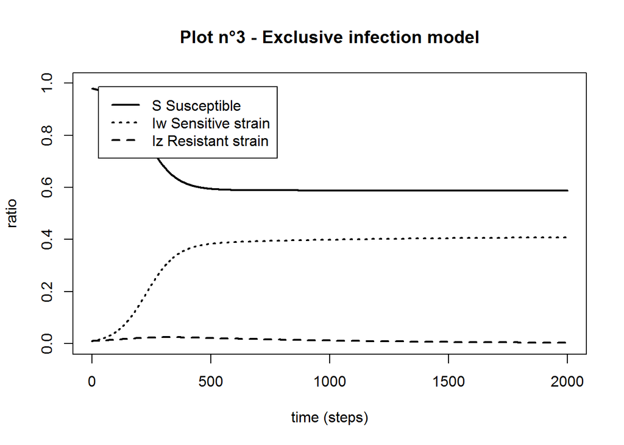

**Plot n°3 Exclusive infection model**: $\beta$ <sub>w</sub> = 0.04, $\beta$ <sub>z</sub> = 0.015, $\gamma$ = 0.01, $\gamma$`= 0.1, $\epsilon$ = 0.15 and $q$=0.5 are the chosen values of parameters. We follow the evolution of the sensitive subpopulation (*solid line*), the subpopulation infected with sensitive strain exclusively (*dotted line*) and with resistant strain exclusively (*dashed line*) over 2000 steps.

## Replacement infection model

In this model, when a patient infected with resistant strain is super-infected by sensistive strain, the latter will replace the first one.

The model is defined by following equations:

$$\begin{aligned}
\frac{dS}{dt} &=-{\beta_w} \times{I_w}\times{S} - {\beta_z} \times{I_z}\times{S} + {\gamma} \times {I_z} + {\gamma}\times(1-{\epsilon})\times{I_w} + {\gamma `} \times {\epsilon} \times {I_w} \\
\frac{dI_w}{dt} &={\beta_w} \times{I_w}\times{S} + ({\beta_w}-{\beta_z})\times{I_w}\times{I_z} - {\gamma}\times(1-{\epsilon})\times{I_w}- {\gamma `} \times {\epsilon} \times {I_w} \\
\frac{dI_z}{dt} &={\beta_z} \times{I_z}\times{S} - {\gamma} \times {I_z} - ({\beta_w} - {\beta_z})\times{I_w}\times{I_z} \\
\end{aligned}$$

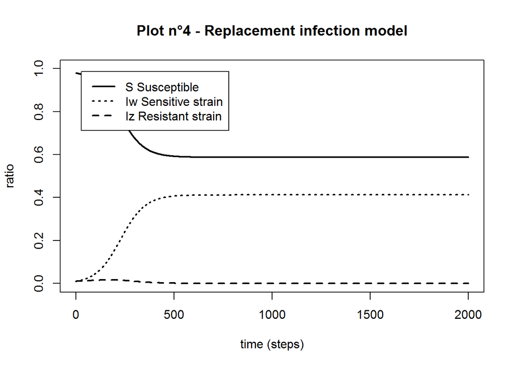

**Plot n°4 Replacement infection model**: $\beta$ <sub>w</sub> = 0.04, $\beta$ <sub>z</sub> = 0.015, $\gamma$ = 0.01, $\gamma$`= 0.1 and $\epsilon$ = 0.15 are the chosen values of parameters. We follow the evolution of the sensitive subpopulation (*solid line*), the subpopulation infected with sensitive strain exclusively (*dotted line*) and with resistant strain exclusively (*dashed line*) over 2000 steps.

## Unidirectional conversion model

In this model, a patient patient that is treated by antibiotics and that is infected by sensitive strain will become infected by a resistant one as the outcome of the antibiotic treatment. This step modelizes clinical treatment failure where instead of cleansing the infection, the pathogen becomes resistant. The parameter $\rho$ represents the probability or frequence of clinical failure.

The model is defined by following equations:

$$\begin{aligned}
\frac{dS}{dt} &=-{\beta_w} \times{I_w}\times{S} - {\beta_z} \times{I_z}\times{S} + {\gamma} \times {I_z} + {\gamma}\times(1-{\epsilon})\times{I_w} + {\gamma `} \times {\epsilon} \times {I_w} \\
\frac{dI_w}{dt} &={\beta_w}\times{I_w}\times{S}-{\gamma}\times(1-{\epsilon})\times{I_w}-{\gamma `}\times{\epsilon}\times{I_w}-{\rho}\times{\epsilon}\times{I_w} \\
\frac{dI_z}{dt} &={\beta_z} \times{I_z}\times{S} - {\gamma} \times {I_z} +{\rho}\times{\epsilon}\times{I_w} \\
\end{aligned}$$

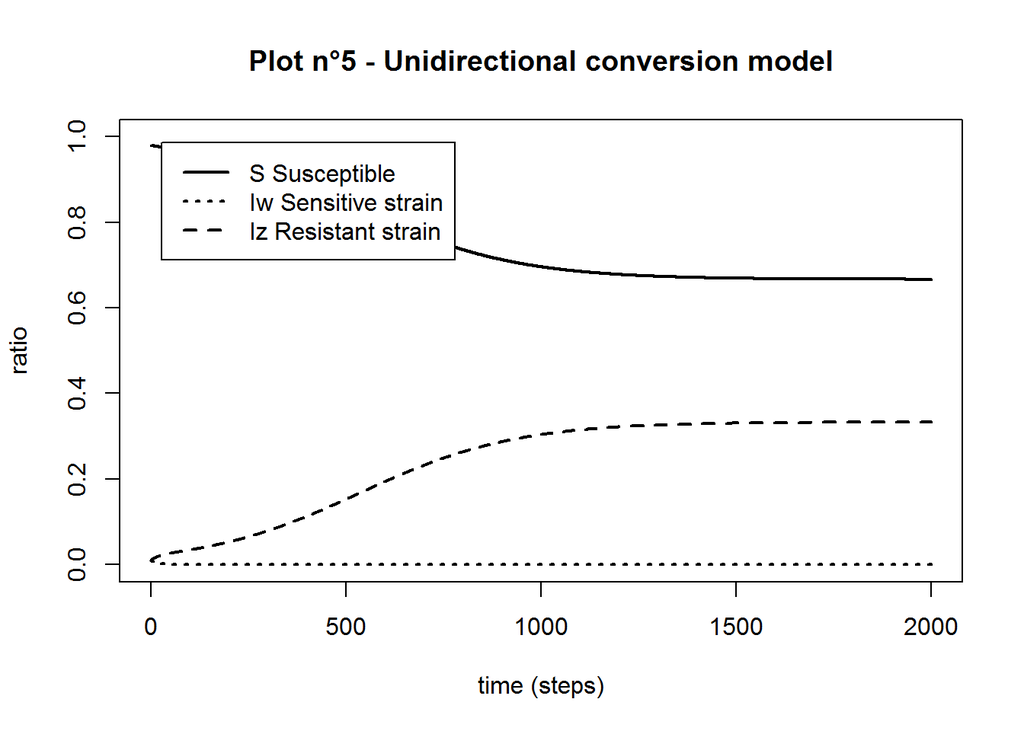

**Plot n°5 Unidirectional conversion model**: $\beta$ <sub>w</sub> = 0.04, $\beta$ <sub>z</sub> = 0.015, $\gamma$ = 0.01, $\gamma$`= 0.1, $\epsilon$ = 0.15 and $\rho$ = 0.5 are the chosen values of parameters. We follow the evolution of the sensitive subpopulation (*solid line*), the subpopulation infected with sensitive strain exclusively (*dotted line*) and with resistant strain exclusively (*dashed line*) over 2000 steps.

## Bidirectional conversion model

In addition to the preceding model, a transition from $Iz$ to $Iw$ is taken into account. In the absence of treatment, some resistant bacteria may revert into sensitive state. These will then be able of outcompeting the resistant one. $\phi$ is the rate at which this phenomenon takes place in untreated patients.

The model is defined by following equations:

$$\begin{aligned}
\frac{dS}{dt} &=-{\beta_w} \times{I_w}\times{S} - {\beta_z} \times{I_z}\times{S} + {\gamma} \times {I_z} + {\gamma}\times(1-{\epsilon})\times{I_w} + {\gamma `} \times {\epsilon} \times {I_w} \\
\frac{dI_w}{dt} &={\beta_w}\times{I_w}\times{S}-{\gamma}\times(1 - {\epsilon})\times{I_w} - {\gamma `}\times{\epsilon}\times{I_w} - {\rho}\times{\epsilon}\times{I_w} - {\phi}\times(1 - {\epsilon})\times{I_z} \\
\frac{dI_z}{dt} &={\beta_z} \times{I_z}\times{S} - {\gamma} \times {I_z} +{\rho}\times{\epsilon}\times{I_w} + {\phi}\times(1-{\epsilon})\times{I_z} \\
\end{aligned}$$

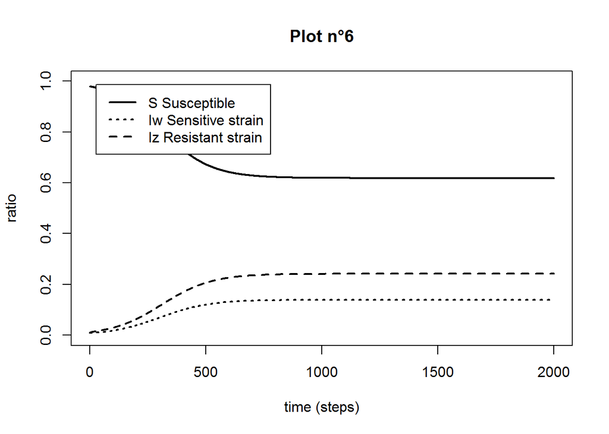

**Plot n°6 Bidirectional conversion model**: $\beta$ <sub>w</sub> = 0.04, $\beta$ <sub>z</sub> = 0.015, $\gamma$ = 0.01, $\gamma$`= 0.1, $\epsilon$ = 0.15, $\rho$ = 0.5 and $\phi$= 0.05 are the chosen values of parameters. We follow the evolution of the sensitive subpopulation (*solid line*), the subpopulation infected with sensitive strain exclusively (*dotted line*) and with resistant strain exclusively (*dashed line*) over 2000 steps.